# Master’s Thesis

Maria del Mar Escalas Martorell

2023-06-19

Load libraries.

```r
# General libraries:
library(tidyverse)
library(stringr) # regex
library(lubridate) # operations with dates

# Plots and tables edition:
library(ggplot2)
library(RColorBrewer)
library(sf) # geometry polygons
library(zoo) # date (quarters)

# Times New Roman font import:
library(extrafont)
```

## 1. INTRODUCTION

### 1.1. Motivation of the work

No code

### 1.2. Ojectives

No code

### 1.3. Methodology

No code

### 1.4. Technical requirements and precautions

No code

## 2. ANALYSIS OF THE SITUATION

### 2.1. Prices of dwellings in Spain

#### Plot 1: Housing Price Index (HPI) variation over time (quarters)

Reading raw data from .csv file.

```r
hpi <- read_delim("Data/dwelling_price_index_INE.csv",
                  delim = ";", skip = 1, col_types = "c",
                  col_names = c("remove1", "Group", "remove2", "remove3", "Period", "HPI")) %>%
  select(-c("remove1", "remove2", "remove3"))

head(hpi)
```

```
## # A tibble: 6 × 3
##   Group Period HPI
##   <chr> <chr>  <chr>
## 1 <NA>  2022T4 -0,8
## 2 <NA>  2022T3 1,7
## 3 <NA>  2022T2 1,9
## 4 <NA>  2022T1 2,6
## 5 <NA>  2021T4 1,2
## 6 <NA>  2021T3 2,1
```

Organizing the dataframe information:

- Substituting *NAs* in *Group* column by *Total National*.
- Substituting *Madrid* in *Group* column by *Community of Madrid*.
- Substituting commas per dots in *HPI* and converting to numeric column type.

```r
hpi <- hpi %>%
  mutate(Group = ifelse(is.na(Group), "Total national",
                        sub(".*Madrid.*", "Community of Madrid", Group)),
         HPI = as.numeric(sub(",", ".", HPI)),
         Period = str_replace(Period, "T", ""))

head(hpi)
```

```
## # A tibble: 6 × 3
##   Group          Period   HPI
##   <chr>          <chr>  <dbl>
## 1 Total national 20224   -0.8
## 2 Total national 20223    1.7
## 3 Total national 20222    1.9
## 4 Total national 20221    2.6
## 5 Total national 20214    1.2
## 6 Total national 20213    2.1
```

Plotting:

- Formatting *Period* information into year quarters.

```r
hpi <- hpi %>%
  mutate(Period = as.yearqtr(format(Period), "%Y%q"))
```

- By default, R may not have *Times New Roman* font available for use in plots. However, this font is commonly installed on most operating systems. To ensure its availability in R, the user should consult the following commented chunk.

```r
# font_import() # to import all fonts from the device
# loadfonts(device = "win") # to load fonts in the session and use them in plots
# fonts() # to check the available fonts for use in R
```

- Plot.

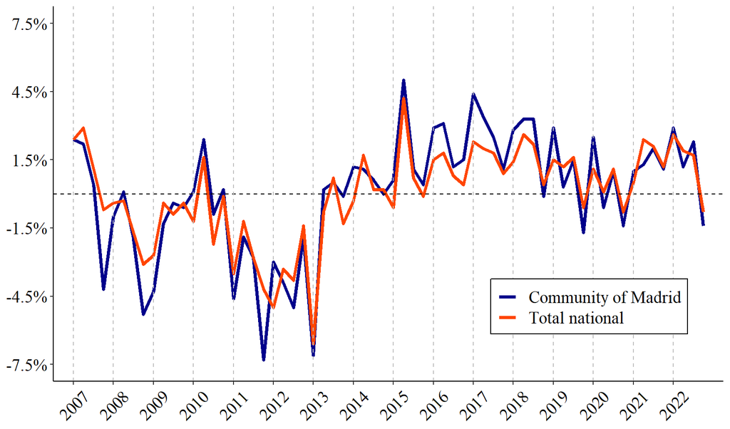

```r
hpi %>%
  ggplot(aes(y = HPI, x = Period, group = Group, color = Group)) +
  geom_line(linewidth = 1.3) +
  labs(x = NULL, y = NULL) +
  theme(legend.title = element_blank(),
        legend.position = c(0.80, 0.20),
        legend.background = element_rect(color = "black", fill = "white"),
        axis.text.x = element_text(angle = 45, vjust = 0.5, color = "black"),
        axis.text.y = element_text(angle = 0, hjust = 1, color = "black"),
        axis.line = element_line(color = "black"),
        panel.grid.major = element_blank(),
        panel.grid.minor = element_blank(),
        panel.background = element_rect(fill = "white"),
        legend.spacing.y = unit(0.03, "cm"), # to adjust legend box
        legend.key = element_rect(fill = "transparent"),
        text = element_text(family = "Times New Roman", size = 18, color = "black")) +
  scale_color_manual(values = c("darkblue", "orangered")) +
  geom_hline(yintercept = 0, linetype = "dashed", color = "black", linewidth = 0.5) +
  scale_y_continuous(limits = c(-7.5, 7.5), breaks = seq(-7.5, 7.5, by = 3),
                     labels = function(x) paste0(x, "%")) + # to add "%" symbol to y-labels
  scale_x_yearqtr(format = "%Y", # format = "%YQ%q" to put QX after each label
                  limits = c(min(hpi$Period), max(hpi$Period)),
                  breaks = seq(from = min(hpi$Period), to = max(hpi$Period), by = 1),
                  expand = c(0, 0.5)) +
  geom_vline(xintercept = as.numeric(seq(min(hpi$Period), max(hpi$Period), by = 1)),
             linetype = "dashed",
             color = "grey")
```

### 2.2. Prices of dwellings in the City of Madrid

#### Data bank from Madrid Council - Statistical information (for plots 2 and 3)

Loading full raw data:

```r
madrid_m2 <- read_delim("Data/price_m2_Madrid_district_neighbourhood.csv",
                        delim = ";", skip = 5,
                        n_max = 161, # to skip last 4 rows
                        col_names = c("District", "Neighbourhood", "2017", "2018", "2019", "2020", "2021", "2022"),
                        show_col_types = FALSE) %>%
  mutate(across(starts_with("20"), ~as.numeric(str_replace_all(., "\\.", "")))) # to substitute dots per nothing and convert to numeric

madrid_m2
```

```
## # A tibble: 161 × 8
##    District         Neighbourhood    `2017` `2018` `2019` `2020` `2021` `2022`
##    <chr>            <chr>             <dbl>  <dbl>  <dbl>  <dbl>  <dbl>  <dbl>
##  1 Ciudad de Madrid Ciudad de Madrid   3285   3844   3732   3682   3700   3939
##  2 01. Centro       01. Centro         4599   4975   5096   4865   4842   5205
##  3 01. Centro       011. Palacio       4474   4873   4852   4703   4714   5029
##  4 01. Centro       012. Embajadores   4017   4239   4479   4180   4231   4333
##  5 01. Centro       013. Cortes        4842   5106   5272   5206   5041   6033
##  6 01. Centro       014. Justicia      5252   5989   5893   5641   5773   5873
##  7 01. Centro       015. Universidad   4639   5068   5282   5019   5144   5473
##  8 01. Centro       016. Sol           5027   5263   5110   5071   4769   6045
##  9 02. Arganzuela   02. Arganzuela     3529   3919   3983   3888   4059   4331
## 10 02. Arganzuela   021. Imperial      3382   3896   3922   3895   4359   4346
## # ℹ 151 more rows
```

#### Plot 2: Average price per square meter of second-hand dwellings by District in 2022, in euros. Increase in price per square meter: 2017 vs. 2022, in %

```r
madrid_districts <- madrid_m2 %>%
  filter(str_detect(Neighbourhood, '^\\d{2}\\.') | Neighbourhood == "Ciudad de Madrid") %>% # to select from the "Neighbourhood" column rows starting by two digits, followed by a dot or rows which are "Ciudad de Madrid"
  rename("remove" = "District", "District" = "Neighbourhood") %>%
  select(-"remove")

madrid_districts
```

```
## # A tibble: 22 × 7
##    District                `2017` `2018` `2019` `2020` `2021` `2022`
##    <chr>                    <dbl>  <dbl>  <dbl>  <dbl>  <dbl>  <dbl>
##  1 Ciudad de Madrid          3285   3844   3732   3682   3700   3939
##  2 01. Centro                4599   4975   5096   4865   4842   5205
##  3 02. Arganzuela            3529   3919   3983   3888   4059   4331
##  4 03. Retiro                4353   4791   4572   4502   4733   5017
##  5 04. Salamanca             5479   6043   5872   5740   6088   6633
##  6 05. Chamartín             4564   5016   5070   4999   5110   5590
##  7 06. Tetuán                3151   3601   3635   3649   3676   4051
##  8 07. Chamberí              4811   5200   5304   5283   5427   5870
##  9 08. Fuencarral-El Pardo   3174   3463   3548   3491   3617   3807
## 10 09. Moncloa-Aravaca       3915   4221   3946   3912   4075   4291
## # ℹ 12 more rows
```

```r
madrid_districts <- madrid_districts %>%
  mutate(District = gsub("^\\d{2}\\.\\s*", "", District), # to remove two initial digits and point from each row in "District"
         District = ifelse(District == "Ciudad de Madrid", "City of Madrid", District), # to manually translate into English
         Variation = round(((`2022` - `2017`) / `2017`) * 100, 2)) # to create a new column with the increase between first and last year

madrid_districts
```

```
## # A tibble: 22 × 8
##    District            `2017` `2018` `2019` `2020` `2021` `2022` Variation
##    <chr>                <dbl>  <dbl>  <dbl>  <dbl>  <dbl>  <dbl>     <dbl>
##  1 City of Madrid        3285   3844   3732   3682   3700   3939      19.9
##  2 Centro                4599   4975   5096   4865   4842   5205      13.2
##  3 Arganzuela            3529   3919   3983   3888   4059   4331      22.7
##  4 Retiro                4353   4791   4572   4502   4733   5017      15.2
##  5 Salamanca             5479   6043   5872   5740   6088   6633      21.1
##  6 Chamartín             4564   5016   5070   4999   5110   5590      22.5
##  7 Tetuán                3151   3601   3635   3649   3676   4051      28.6
##  8 Chamberí              4811   5200   5304   5283   5427   5870      22.0
##  9 Fuencarral-El Pardo   3174   3463   3548   3491   3617   3807      19.9
## 10 Moncloa-Aravaca       3915   4221   3946   3912   4075   4291       9.6
## # ℹ 12 more rows
```

Plotting:

- Preparing data in long format.

```r
madrid_longer <- madrid_districts %>%
  pivot_longer(!District, names_to = c("Year"), values_to = "price per m2")

madrid_longer
```

```
## # A tibble: 154 × 3
##    District       Year      `price per m2`
##    <chr>          <chr>              <dbl>
##  1 City of Madrid 2017              3285
##  2 City of Madrid 2018              3844
##  3 City of Madrid 2019              3732
##  4 City of Madrid 2020              3682
##  5 City of Madrid 2021              3700
##  6 City of Madrid 2022              3939
##  7 City of Madrid Variation           19.9
##  8 Centro         2017              4599
##  9 Centro         2018              4975
## 10 Centro         2019              5096
## # ℹ 144 more rows
```

- Plot.

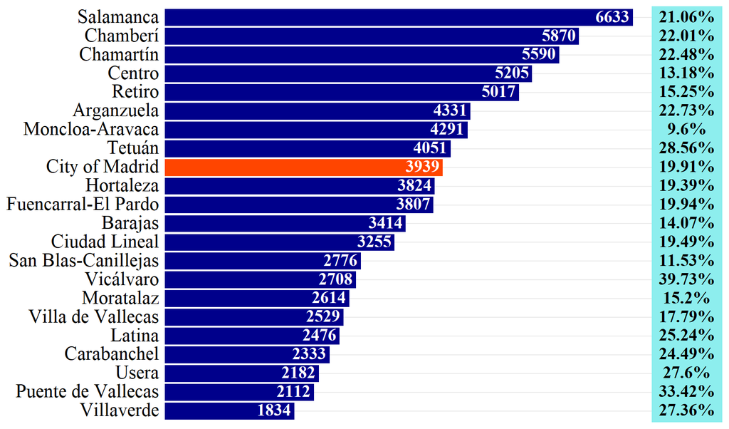

```r
madrid_longer %>%
  filter(Year == "2022") %>%
  ggplot(aes(x = reorder(District, `price per m2`), y = `price per m2`, fill = (District == "City of Madrid"))) +
  labs(x = NULL, y = NULL) +
  geom_bar(stat = "identity") +
  coord_flip() +
  geom_rect(xmin = -Inf, xmax = Inf, ymin = 6900, ymax = 7900, fill = "darkslategray2") +
  geom_text(aes(label = `price per m2`),
            hjust = 1.1, nudge_x = 0.1, color = "white", family = "Times New Roman", size = 5, fontface = "bold") +
  scale_y_continuous(limits = c(0, 7900), expand = c(0, 0), breaks = NULL) +
  geom_text(data = madrid_longer %>% filter(Year == "Variation"),
            aes(x = District, y = 7400, label = paste0(`price per m2`, "%")),
            vjust = 0.35, family = "Times New Roman", size = 5, fontface = "bold") +
  theme_minimal() +
  theme(text = element_text(family = "Times New Roman", size = 20),
        axis.text.y = element_text(vjust = 0.35, color = "black")) +
  scale_fill_manual(values = c("TRUE" = "orangered", "FALSE" = "darkblue"), guide = "none") # to fill "City of Madrid" distinct from distrits
```

#### Plot 3: Average price per sq meter of Districts in Madrid

- Filtering to remove aggregated data from *City of Madrid* and leave only data from individual districts.

```r
madrid_map <- madrid_m2 %>%
  filter(str_detect(Neighbourhood,'^\\d{2}\\.')) %>% # start by two digits followed by a dot
  rename("remove" = "District", "District" = "Neighbourhood") %>%
  select(-"remove")

madrid_map
```

```
## # A tibble: 21 × 7
##    District                `2017` `2018` `2019` `2020` `2021` `2022`
##    <chr>                    <dbl>  <dbl>  <dbl>  <dbl>  <dbl>  <dbl>
##  1 01. Centro                4599   4975   5096   4865   4842   5205
##  2 02. Arganzuela            3529   3919   3983   3888   4059   4331
##  3 03. Retiro                4353   4791   4572   4502   4733   5017
##  4 04. Salamanca             5479   6043   5872   5740   6088   6633
##  5 05. Chamartín             4564   5016   5070   4999   5110   5590
##  6 06. Tetuán                3151   3601   3635   3649   3676   4051
##  7 07. Chamberí              4811   5200   5304   5283   5427   5870
##  8 08. Fuencarral-El Pardo   3174   3463   3548   3491   3617   3807
##  9 09. Moncloa-Aravaca       3915   4221   3946   3912   4075   4291
## 10 10. Latina                1977   2307   2299   2246   2270   2476
## # ℹ 11 more rows
```

- Loading geospatial data to create the map of Madrid and its districts.

```r
geodata_districts <- read_sf(dsn = "./Data", # "." means current directory
  layer = "Geodata_Districts")

geodata_districts <- geodata_districts %>%
  mutate(NOMBRE = case_when(NOMBRE == "San Blas - Canillejas" ~ "San Blas-Canillejas",
                            NOMBRE == "Fuencarral - El Pardo" ~ "Fuencarral-El Pardo",
                            NOMBRE == "Moncloa - Aravaca" ~ "Moncloa-Aravaca",
                            TRUE ~ NOMBRE),
         District = paste0(COD_DIS_TX, ". ", NOMBRE)) %>% select(District)

geodata_districts
```

```
## Simple feature collection with 21 features and 1 field
## Geometry type: POLYGON
## Dimension:     XY
## Bounding box:  xmin: 424753.5 ymin: 4462566 xmax: 456033.3 ymax: 4499365
## Projected CRS: ETRS89 / UTM zone 30N
## # A tibble: 21 × 2
##    District                                                             geometry
##    <chr>                                                           <POLYGON [m]>
##  1 01. Centro             ((441184.8 4473201, 441181.2 4473184, 441178.9 447316…
##  2 10. Latina             ((438689.6 4473669, 438753.9 4473349, 438719.1 447320…
##  3 11. Carabanchel        ((438958.7 4472385, 438985 4472384, 438988.7 4472384,…
##  4 12. Usera              ((441997.9 4468465, 441998 4468437, 442003.1 4468403,…
##  5 13. Puente de Vallecas ((442425.7 4468012, 442368.3 4468011, 442316.9 446801…
##  6 14. Moratalaz          ((445456.6 4473964, 445620.9 4473953, 445778.8 447395…
##  7 15. Ciudad Lineal      ((447238.9 4474064, 447261.3 4474023, 447283 4473981,…
##  8 16. Hortaleza          ((444730.5 4484729, 444724.5 4484694, 444733.9 448469…
##  9 17. Villaverde         ((440255.3 4468348, 440291.3 4468347, 440343.8 446834…
## 10 18. Villa de Vallecas  ((448475.3 4470851, 448523.7 4470805, 448534.4 447081…
## # ℹ 11 more rows
```

- Adding to each district its corresponding geometry polygon.

```r
madrid_map <- madrid_map %>% left_join(geodata_districts, by = "District")

madrid_map
```

```
## # A tibble: 21 × 8
##    District  `2017` `2018` `2019` `2020` `2021` `2022`                  geometry
##    <chr>      <dbl>  <dbl>  <dbl>  <dbl>  <dbl>  <dbl>             <POLYGON [m]>
##  1 01. Cent…   4599   4975   5096   4865   4842   5205 ((441184.8 4473201, 4411…
##  2 02. Arga…   3529   3919   3983   3888   4059   4331 ((440272.9 4472970, 4403…
##  3 03. Reti…   4353   4791   4572   4502   4733   5017 ((443652.1 4473313, 4435…
##  4 04. Sala…   5479   6043   5872   5740   6088   6633 ((444075.2 4476612, 4440…
##  5 05. Cham…   4564   5016   5070   4999   5110   5590 ((442907 4481553, 442901…
##  6 06. Tetu…   3151   3601   3635   3649   3676   4051 ((440864 4480662, 440875…
##  7 07. Cham…   4811   5200   5304   5283   5427   5870 ((441380 4477514, 441331…
##  8 08. Fuen…   3174   3463   3548   3491   3617   3807 ((445503.2 4498783, 4456…
##  9 09. Monc…   3915   4221   3946   3912   4075   4291 ((432093.7 4480172, 4321…
## 10 10. Lati…   1977   2307   2299   2246   2270   2476 ((438689.6 4473669, 4387…
## # ℹ 11 more rows
```

- Plot. Two digit code of each district and name is placed after code sections for a better understanding.

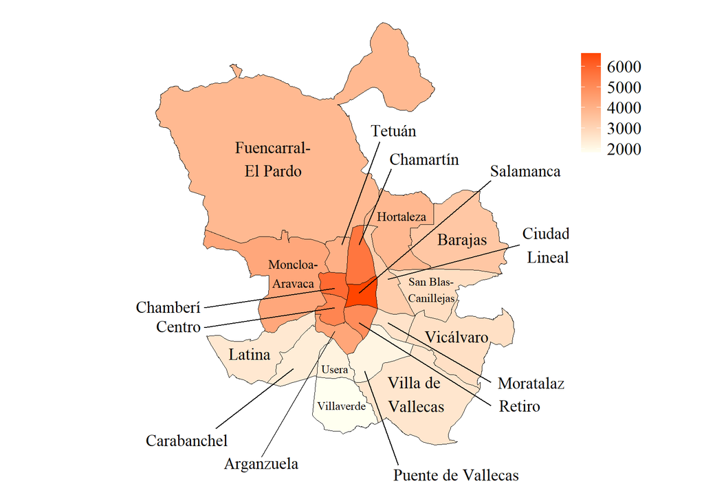

```r
madrid_map %>%
ggplot(aes(fill = `2022`, geometry = geometry)) +
  geom_sf(color = "black") +
  scale_fill_gradient(low = "ivory", high = "orangered") +
  labs(x = NULL, y = NULL) +
  theme_void() +
  theme(text = element_text(family="Times New Roman"),
        legend.title = element_blank(),
        legend.key = element_blank(),
        legend.position = c(1.1, 0.8),
        legend.direction = "vertical",
        legend.text = element_text(size = 15),
        plot.margin = margin(0, 0, 0, 0, "pt"))  +
  annotate("text", x = 426800, y = 4472900, label = "Centro", # 01.
           size = 5, family = "Times New Roman") +
  annotate("text", x = 434000, y = 4461000, label = "Arganzuela", # 02.
           size = 5, family = "Times New Roman") +
  annotate("text", x = 456500, y = 4466000, label = "Retiro", # 03.
           size = 5, family = "Times New Roman") +
  annotate("text", x = 457000, y = 4486500, label = "Salamanca", # 04.
           size = 5, family = "Times New Roman") +
  annotate("text", x = 448200, y = 4487500, label = "Chamartín", # 05.
           size = 5, family = "Times New Roman") +
  annotate("text", x = 445500, y = 4490000, label = "Tetuán", # 06.
           size = 5, family = "Times New Roman") +
  annotate("text", x = 425900, y = 4474600, label = "Chamberí", # 07.
           size = 5, family = "Times New Roman") +
  annotate("text", x = 435000, y = 4487500, label = "Fuencarral-\nEl Pardo", # 08.
           size = 5, family = "Times New Roman") +
  annotate("text", x = 436800, y = 4477500, label = "Moncloa-\nAravaca", # 09.
           size = 4, family = "Times New Roman") +
  annotate("text", x = 433000, y = 4470500, label = "Latina", # 10.
           size = 5, family = "Times New Roman") +
  annotate("text", x = 427500, y = 4463000, label = "Carabanchel", # 11.
           size = 5, family = "Times New Roman") +
  annotate("text", x = 440400, y = 4469200, label = "Usera", # 12.
           size = 3.5, family = "Times New Roman") +
  annotate("text", x = 451000, y = 4460000, label = "Puente de Vallecas", # 13.
           size = 5, family = "Times New Roman") +
  annotate("text", x = 457500, y = 4468000, label = "Moratalaz", # 14.
           size = 5, family = "Times New Roman") +
  annotate("text", x = 459000, y = 4480000, label = "Ciudad \nLineal", # 15.
           size = 5, family = "Times New Roman") +
  annotate("text", x = 446200, y = 4482500, label = "Hortaleza", # 16.
           size = 4, family = "Times New Roman") +
  annotate("text", x = 441000, y = 4466000, label = "Villaverde", # 17.
           size = 3.5, family = "Times New Roman") +
  annotate("text", x = 447500, y = 4467000, label = "Villa de \nVallecas", # 18.
           size = 5, family = "Times New Roman") +
  annotate("text", x = 451000, y = 4472000, label = "Vicálvaro", # 19.
           size = 5, family = "Times New Roman") +
  annotate("text", x = 448800, y = 4476100, label = "San Blas-\nCanillejas", # 20.
           size = 3.5, family = "Times New Roman") +
  annotate("text", x = 451500, y = 4480500, label = "Barajas", # 21.
            size = 5, family = "Times New Roman") +
  geom_segment(aes(x = 429000, y = 4472800, xend = 440400, yend = 4474500), # 01. Centro
               linewidth = 0.5, color = "black") +
  geom_segment(aes(x = 434000, y = 4461500, xend = 440400, yend = 4472500), # 02. Arganzuela
               linewidth = 0.5, color = "black") +
  geom_segment(aes(x = 442500, y = 4473200, xend = 454000, yend = 4466000), # 03. Retiro
               linewidth = 0.5, color = "black") +
  geom_segment(aes(x = 442500, y = 4475800, xend = 454000, yend = 4485600), # 04. Salamanca
               linewidth = 0.5, color = "black") +
  geom_segment(aes(x = 442500, y = 4480000, xend = 445300, yend = 4486600), # 05. Chamartín
               linewidth = 0.5, color = "black") +
  geom_segment(aes(x = 441000, y = 4480000, xend = 444300, yend = 4489000), # 06. Tetuán
               linewidth = 0.5, color = "black") +
  geom_segment(aes(x = 429000, y = 4474500, xend = 440400, yend = 4476200), # 07. Chamberí
               linewidth = 0.5, color = "black") +
  geom_segment(aes(x = 430000, y = 4464000, xend = 436800, yend = 4469200), # 11. Carabanchel
               linewidth = 0.5, color = "black") +
  geom_segment(aes(x = 443000, y = 4469000, xend = 445900, yend = 4460800), # 13. Puente de Vallecas
               linewidth = 0.5, color = "black") +
  geom_segment(aes(x = 445000, y = 4473200, xend = 454000, yend = 4468000), # 14. Moratalaz
               linewidth = 0.5, color = "black") +
  geom_segment(aes(x = 445000, y = 4477000, xend = 456500, yend = 4480000), # 15. Ciudad Lineal
               linewidth = 0.5, color = "black")
```

## REFERENCES

CSSLab UC3M (2023). Data Visualization: Principles and Practice. Retrieved April 4, 2023, from https://csslab.uc3m.es/dataviz/

Medina M. (2023). R Programming. University Carlos III of Madrid.

National Institute for Statistics – Spain. (2023). Índice de Precios de Vivienda [Housing Price Index]. Retrieved March 15, 2023, from https://www.ine.es/jaxiT3/Datos.htm?t=25171

Open Data Portal of Madrid City Council. (2023). Evolution of the price of second-hand housing (€ per square meter) by District and Neighbourhood. Retrieved April 2, 2023, from https://www-s.madrid.es/CSEBD_WBINTER/seleccionSerie.html?numSerie=0504030000202

Open Data Portal of Madrid City Council. (2021). Madrid municipal districts (geospatial data). Retrieved May 15, 2023, from https://www-s.madrid.es/CSEBD_WBINTER/seleccionSerie.html?numSerie=0504030000202